# Machine Learning: AllLife Bank Personal Loan Campaign

## Problem Statement

### Context

AllLife Bank is a US bank that has a growing customer base. The majority of these customers are liability customers (depositors) with varying sizes of deposits. The number of customers who are also borrowers (asset customers) is quite small, and the bank is interested in expanding this base rapidly to bring in more loan business and in the process, earn more through the interest on loans. In particular, the management wants to explore ways of converting its liability customers to personal loan customers (while retaining them as depositors).

A campaign that the bank ran last year for liability customers showed a healthy conversion rate of over 9% success. This has encouraged the retail marketing department to devise campaigns with better target marketing to increase the success ratio.

You as a Data scientist at AllLife bank have to build a model that will help the marketing department to identify the potential customers who have a higher probability of purchasing the loan.

### Objective

To predict whether a liability customer will buy personal loans, to understand which customer attributes are most significant in driving purchases, and identify which segment of customers to target more.

### Data Dictionary

- `ID`: Customer ID
- `Age`: Customer’s age in completed years
- `Experience`: #years of professional experience
- `Income`: Annual income of the customer (in thousand dollars)
- `ZIP Code`: Home Address ZIP code.
- `Family`: the Family size of the customer
- `CCAvg`: Average spending on credit cards per month (in thousand dollars)
- `Education`: Education Level. 1: Undergrad; 2: Graduate;3: Advanced/Professional
- `Mortgage`: Value of house mortgage if any. (in thousand dollars)
- `Personal_Loan`: Did this customer accept the personal loan offered in the last campaign? (0: No, 1: Yes)
- `Securities_Account`: Does the customer have securities account with the bank? (0: No, 1: Yes)
- `CD_Account`: Does the customer have a certificate of deposit (CD) account with the bank? (0: No, 1: Yes)
- `Online`: Do customers use internet banking facilities? (0: No, 1: Yes)
- `CreditCard`: Does the customer use a credit card issued by any other Bank (excluding All life Bank)? (0: No, 1: Yes)

## Importing necessary libraries

```python
# Installing the libraries with the specified version.
!pip install numpy==1.25.2 pandas==1.5.3 matplotlib==3.7.1 seaborn==0.13.1 scikit-learn==1.2.2 sklearn-pandas==2.2.0 -q --user
```

**Note**: *After running the above cell, kindly restart the notebook kernel and run all cells sequentially from the start again.*

```python
import numpy as np
import pandas as pd
import matplotlib.pyplot as plt
import seaborn as sns



from sklearn.model_selection import train_test_split
from sklearn import tree
from sklearn.tree import DecisionTreeClassifier
from sklearn.model_selection import GridSearchCV

from sklearn.metrics import (
    f1_score,
    accuracy_score,
    recall_score,
    precision_score,
    confusion_matrix,
    make_scorer,
)

import scipy.stats
import warnings
warnings.filterwarnings("ignore")  # ignore warnings

%matplotlib inline
sns.set()
```

## Loading the dataset

```python
loan=pd.read_csv('Loan_Modelling.csv')
```

```python
df=loan.copy()
```

## Data Overview

- Observations
- Sanity checks

### Head and Tail

```python
df.head()
```

|  | ID | Age | Experience | Income | ZIPCode | Family | CCAvg | Education | Mortgage | Personal_Loan | Securities_Account | CD_Account | Online | CreditCard |
| --- | --- | --- | --- | --- | --- | --- | --- | --- | --- | --- | --- | --- | --- | --- |
| 0 | 1 | 25 | 1 | 49 | 91107 | 4 | 1.6 | 1 | 0 | 0 | 1 | 0 | 0 | 0 |
| 1 | 2 | 45 | 19 | 34 | 90089 | 3 | 1.5 | 1 | 0 | 0 | 1 | 0 | 0 | 0 |
| 2 | 3 | 39 | 15 | 11 | 94720 | 1 | 1.0 | 1 | 0 | 0 | 0 | 0 | 0 | 0 |
| 3 | 4 | 35 | 9 | 100 | 94112 | 1 | 2.7 | 2 | 0 | 0 | 0 | 0 | 0 | 0 |
| 4 | 5 | 35 | 8 | 45 | 91330 | 4 | 1.0 | 2 | 0 | 0 | 0 | 0 | 0 | 1 |

```python
df.tail()
```

|  | ID | Age | Experience | Income | ZIPCode | Family | CCAvg | Education | Mortgage | Personal_Loan | Securities_Account | CD_Account | Online | CreditCard |
| --- | --- | --- | --- | --- | --- | --- | --- | --- | --- | --- | --- | --- | --- | --- |
| 4995 | 4996 | 29 | 3 | 40 | 92697 | 1 | 1.9 | 3 | 0 | 0 | 0 | 0 | 1 | 0 |
| 4996 | 4997 | 30 | 4 | 15 | 92037 | 4 | 0.4 | 1 | 85 | 0 | 0 | 0 | 1 | 0 |
| 4997 | 4998 | 63 | 39 | 24 | 93023 | 2 | 0.3 | 3 | 0 | 0 | 0 | 0 | 0 | 0 |
| 4998 | 4999 | 65 | 40 | 49 | 90034 | 3 | 0.5 | 2 | 0 | 0 | 0 | 0 | 1 | 0 |
| 4999 | 5000 | 28 | 4 | 83 | 92612 | 3 | 0.8 | 1 | 0 | 0 | 0 | 0 | 1 | 1 |

### Data information

```python
# Number of row and columns
df.shape
```

```
(5000, 14)
```

```python
# dtypes: float64(1), int64(13)
df.info()
```

```
<class 'pandas.core.frame.DataFrame'>
RangeIndex: 5000 entries, 0 to 4999
Data columns (total 14 columns):
 #   Column              Non-Null Count  Dtype
---  ------              --------------  -----
 0   ID                  5000 non-null   int64
 1   Age                 5000 non-null   int64
 2   Experience          5000 non-null   int64
 3   Income              5000 non-null   int64
 4   ZIPCode             5000 non-null   int64
 5   Family              5000 non-null   int64
 6   CCAvg               5000 non-null   float64
 7   Education           5000 non-null   int64
 8   Mortgage            5000 non-null   int64
 9   Personal_Loan       5000 non-null   int64
 10  Securities_Account  5000 non-null   int64
 11  CD_Account          5000 non-null   int64
 12  Online              5000 non-null   int64
 13  CreditCard          5000 non-null   int64
dtypes: float64(1), int64(13)
memory usage: 547.0 KB
```

### Statistic

```python
df.describe().T
```

|  | count | mean | std | min | 25% | 50% | 75% | max |
| --- | --- | --- | --- | --- | --- | --- | --- | --- |
| ID | 5000.0 | 2500.500000 | 1443.520003 | 1.0 | 1250.75 | 2500.5 | 3750.25 | 5000.0 |
| Age | 5000.0 | 45.338400 | 11.463166 | 23.0 | 35.00 | 45.0 | 55.00 | 67.0 |
| Experience | 5000.0 | 20.104600 | 11.467954 | -3.0 | 10.00 | 20.0 | 30.00 | 43.0 |
| Income | 5000.0 | 73.774200 | 46.033729 | 8.0 | 39.00 | 64.0 | 98.00 | 224.0 |
| ZIPCode | 5000.0 | 93169.257000 | 1759.455086 | 90005.0 | 91911.00 | 93437.0 | 94608.00 | 96651.0 |
| Family | 5000.0 | 2.396400 | 1.147663 | 1.0 | 1.00 | 2.0 | 3.00 | 4.0 |
| CCAvg | 5000.0 | 1.937938 | 1.747659 | 0.0 | 0.70 | 1.5 | 2.50 | 10.0 |
| Education | 5000.0 | 1.881000 | 0.839869 | 1.0 | 1.00 | 2.0 | 3.00 | 3.0 |
| Mortgage | 5000.0 | 56.498800 | 101.713802 | 0.0 | 0.00 | 0.0 | 101.00 | 635.0 |
| Personal_Loan | 5000.0 | 0.096000 | 0.294621 | 0.0 | 0.00 | 0.0 | 0.00 | 1.0 |
| Securities_Account | 5000.0 | 0.104400 | 0.305809 | 0.0 | 0.00 | 0.0 | 0.00 | 1.0 |
| CD_Account | 5000.0 | 0.060400 | 0.238250 | 0.0 | 0.00 | 0.0 | 0.00 | 1.0 |
| Online | 5000.0 | 0.596800 | 0.490589 | 0.0 | 0.00 | 1.0 | 1.00 | 1.0 |
| CreditCard | 5000.0 | 0.294000 | 0.455637 | 0.0 | 0.00 | 0.0 | 1.00 | 1.0 |

1- No Null Number

2- one float and 13 intiger

```python
# Colimns array of 13 columns
df.columns
```

```
Index(['ID', 'Age', 'Experience', 'Income', 'ZIPCode', 'Family', 'CCAvg',
       'Education', 'Mortgage', 'Personal_Loan', 'Securities_Account',
       'CD_Account', 'Online', 'CreditCard'],
      dtype='object')
```

### data type

```python
df.dtypes
```

```
ID                      int64
Age                     int64
Experience              int64
Income                  int64
ZIPCode                 int64
Family                  int64
CCAvg                 float64
Education               int64
Mortgage                int64
Personal_Loan           int64
Securities_Account      int64
CD_Account              int64
Online                  int64
CreditCard              int64
dtype: object
```

## Exploratory Data Analysis.

- EDA is an important part of any project involving data.
- It is important to investigate and understand the data better before building a model with it.
- A few questions have been mentioned below which will help you approach the analysis in the right manner and generate insights from the data.
- A thorough analysis of the data, in addition to the questions mentioned below, should be done.

**Questions**:

1. What is the distribution of mortgage attribute? Are there any noticeable patterns or outliers in the distribution?
2. How many customers have credit cards?
3. What are the attributes that have a strong correlation with the target attribute (personal loan)?
4. How does a customer's interest in purchasing a loan vary with their age?
5. How does a customer's interest in purchasing a loan vary with their education?

```python
# How many customers have credit cards?
df['CreditCard'].sum()
```

```
1470
```

### What is the distribution of mortgage attribute? Are there any noticeable patterns or outliers in the distribution?

```python
df['Mortgage'].describe()
```

```
count    5000.000000
mean       56.498800
std       101.713802
min         0.000000
25%         0.000000
50%         0.000000
75%       101.000000
max       635.000000
Name: Mortgage, dtype: float64
```

Mortgage has skew to right

```python
# People has No mortgage
df['Mortgage'].value_counts()[0]
```

```
3462
```

```python
# Number unique mortgage
df['Mortgage'].nunique()
```

```
347
```

```python
# Unique mortgage  Length: 347, dtype: int64
df['Mortgage'].value_counts()[:]
```

```
0      3462
98       17
119      16
89       16
91       16
       ...
547       1
458       1
505       1
361       1
541       1
Name: Mortgage, Length: 347, dtype: int64
```

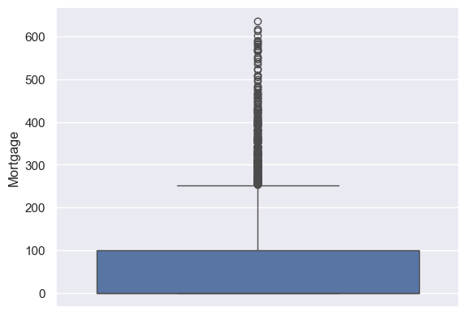

```python
# Mortgage outlier
sns.boxplot(df['Mortgage'])
```

```python
# Numberof people who has no mortgage (Mortgage=0)
len(df[df['Mortgage']==0])
```

```
3462
```

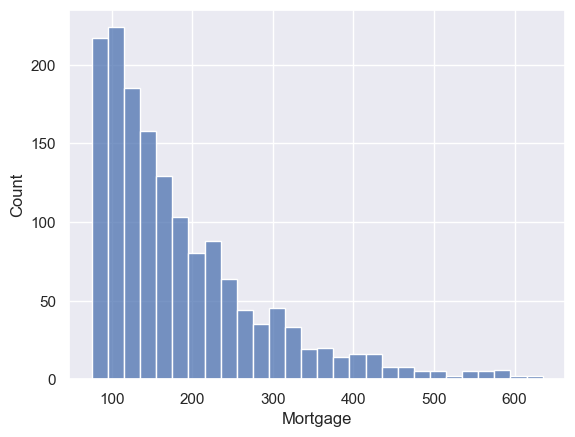

```python
# Plot for who has mortgage
sns.histplot(df[df['Mortgage']>0],x='Mortgage')
```

- Mortgage has a right Skew

### How many customers have credit cards?

```python
# How many customers have credit cards?
df['CreditCard'].sum()
```

```
1470
```

### What are the attributes that have a strong correlation with the target attribute (personal loan)?

```python
# Correlation
df.corr()['Personal_Loan']
```

```
ID                   -0.024801
Age                  -0.007726
Experience           -0.007858
Income                0.502462
ZIPCode              -0.002974
Family                0.061367
CCAvg                 0.366889
Education             0.136722
Mortgage              0.142095
Personal_Loan         1.000000
Securities_Account    0.021954
CD_Account            0.316355
Online                0.006278
CreditCard            0.002802
Name: Personal_Loan, dtype: float64
```

### convert numerical to catigorical variable

```python
# Chang database  New
df_new=df.copy()
```

```python
df_new.head()
```

|  | ID | Age | Experience | Income | ZIPCode | Family | CCAvg | Education | Mortgage | Personal_Loan | Securities_Account | CD_Account | Online | CreditCard |
| --- | --- | --- | --- | --- | --- | --- | --- | --- | --- | --- | --- | --- | --- | --- |
| 0 | 1 | 25 | 1 | 49 | 91107 | 4 | 1.6 | 1 | 0 | 0 | 1 | 0 | 0 | 0 |
| 1 | 2 | 45 | 19 | 34 | 90089 | 3 | 1.5 | 1 | 0 | 0 | 1 | 0 | 0 | 0 |
| 2 | 3 | 39 | 15 | 11 | 94720 | 1 | 1.0 | 1 | 0 | 0 | 0 | 0 | 0 | 0 |
| 3 | 4 | 35 | 9 | 100 | 94112 | 1 | 2.7 | 2 | 0 | 0 | 0 | 0 | 0 | 0 |
| 4 | 5 | 35 | 8 | 45 | 91330 | 4 | 1.0 | 2 | 0 | 0 | 0 | 0 | 0 | 1 |

```python
df_new['Personal_Loan']=df_new['Personal_Loan'].replace(0,'No')
df_new['Personal_Loan']=df_new['Personal_Loan'].replace(1,'Yes')
```

```python
df_new['Mortgage']=df_new['Mortgage'].replace({0:'No',1:'Yes'})
df_new['Securities_Account']=df_new['Securities_Account'].replace({0:'No',1:'Yes'})
df_new['CD_Account']=df_new['CD_Account'].replace({0:'No',1:'Yes'})
df_new['Online']=df_new['Online'].replace({0:'No',1:'Yes'})
df_new['CreditCard']=df_new['CreditCard'].replace({0:'No',1:'Yes'})
```

```python
df_new['Education']=df_new['Education'].replace({1:'Undergraduaate',2:'Graduate',3:'Advanced/Professional'})
```

```python
df_new.head()
```

|  | ID | Age | Experience | Income | ZIPCode | Family | CCAvg | Education | Mortgage | Personal_Loan | Securities_Account | CD_Account | Online | CreditCard |
| --- | --- | --- | --- | --- | --- | --- | --- | --- | --- | --- | --- | --- | --- | --- |
| 0 | 1 | 25 | 1 | 49 | 91107 | 4 | 1.6 | Undergraduaate | No | No | Yes | No | No | No |
| 1 | 2 | 45 | 19 | 34 | 90089 | 3 | 1.5 | Undergraduaate | No | No | Yes | No | No | No |
| 2 | 3 | 39 | 15 | 11 | 94720 | 1 | 1.0 | Undergraduaate | No | No | No | No | No | No |
| 3 | 4 | 35 | 9 | 100 | 94112 | 1 | 2.7 | Graduate | No | No | No | No | No | No |
| 4 | 5 | 35 | 8 | 45 | 91330 | 4 | 1.0 | Graduate | No | No | No | No | No | Yes |

### How does a customer's interest in purchasing a loan vary with their age?

```python
# Correlation Age and Personal_Loan
df['Age'].corr(df['Personal_Loan'], method='pearson')
```

```
-0.00772561717353405
```

```python
# Number of Unique
df_new.groupby('Personal_Loan')['Age'].nunique()
```

```
Personal_Loan
No     45
Yes    40
Name: Age, dtype: int64
```

```python
# grouping how get personal loan based on age
df_new.groupby('Personal_Loan')['Age'].value_counts()
```

```
Personal_Loan  Age
No             35     135
               43     134
               58     133
               52     130
               41     128
                     ...
Yes            40       8
               41       8
               64       8
               31       7
               39       6
Name: Age, Length: 85, dtype: int64
```

```python
# number of how did not get loan
l_no=df_new[df_new['Personal_Loan']=='No']['Age'].value_counts().sum()
l_no
```

```
4520
```

```python
# number of how  get loan
l_yes=df_new[df_new['Personal_Loan']=='Yes']['Age'].value_counts().sum()
l_yes
```

```
480
```

```python
# percentag of don have loan
print('did not get loan=',(l_no/5000)*100,'%')
```

```
did not get loan= 90.4 %
```

```python
# catigory for loan situation
df_new.groupby('Personal_Loan')['Age'].unique()
```

```
Personal_Loan
No     [25, 45, 39, 35, 37, 53, 50, 65, 29, 48, 59, 6...
Yes    [34, 38, 46, 42, 32, 37, 50, 56, 31, 54, 55, 5...
Name: Age, dtype: object
```

[figure not shown]

```python
# Plot for Age and Personal_loan
sns.histplot(df_new,x='Age',hue='Personal_Loan',bins=30,kde=True)
```

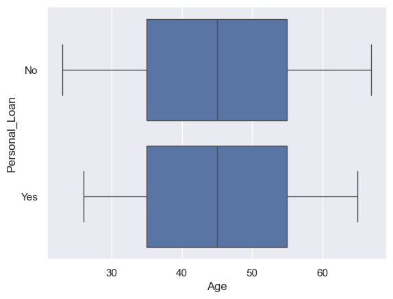

```python
sns.boxplot(df_new,x='Age',y='Personal_Loan')
```

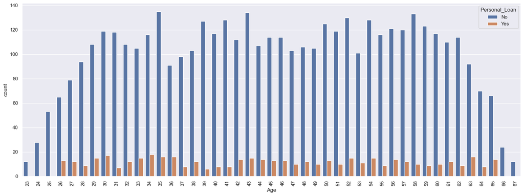

```python
plt.figure(figsize=(20,7))
sns.countplot(df_new,x='Age',hue="Personal_Loan")
plt.xticks(rotation=90)

plt.show()
```

### How does a customer's interest in purchasing a loan vary with their education?

```python
df['Education'].corr(df['Personal_Loan'], method='pearson')
```

```
0.13672155003028072
```

```python
# Number of Unique
df_new.groupby('Personal_Loan')['Education'].unique()
```

```
Personal_Loan
No     [Undergraduaate, Graduate, Advanced/Professional]
Yes    [Advanced/Professional, Graduate, Undergraduaate]
Name: Education, dtype: object
```

```python
# education
df_n=df_new['Education'].value_counts().reset_index()
df_n.rename(columns={'index':'Education','Education':'Ferequently'},inplace=True)
df_n
```

|  | Education | Ferequently |
| --- | --- | --- |
| 0 | Undergraduaate | 2096 |
| 1 | Advanced/Professional | 1501 |
| 2 | Graduate | 1403 |

```python
# grouping how get personal loan based on age
df_new.groupby('Personal_Loan')['Education'].value_counts()
```

```
Personal_Loan  Education
No             Undergraduaate           2003
               Advanced/Professional    1296
               Graduate                 1221
Yes            Advanced/Professional     205
               Graduate                  182
               Undergraduaate             93
Name: Education, dtype: int64
```

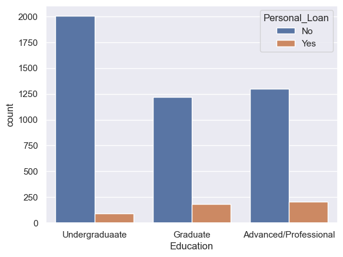

```python
sns.countplot(df_new,x='Education',hue='Personal_Loan')
```

[figure not shown]

```python
df_p=df_new.groupby('Personal_Loan')['Education'].value_counts()
sns.boxplot(dfP,x='Education')
```

### Experience

```python
# Negetive number in experience
(df_new['Experience']<0).value_counts()
```

```
False    4948
True       52
Name: Experience, dtype: int64
```

```python
df_new['Experience'][(df_new['Experience']<0)].unique()
```

```
array([-1, -2, -3], dtype=int64)
```

```python
df_new['Experience'][(df['Experience']<0)].value_counts()
```

```
-1    33
-2    15
-3     4
Name: Experience, dtype: int64
```

```python
(df_new['Experience']).value_counts()[-1]
```

```
33
```

```python
(df_new['Experience']).value_counts()[-2]
```

```
15
```

```python
(df_new['Experience']).value_counts()[-3]
```

```
4
```

```python
# Replace -1 to 1
df_new['Experience']=df_new['Experience'].replace(-1,1)
```

```python
# Replace -2 to 2
df_new['Experience']=df_new['Experience'].replace(-2,2)
```

```python
# Replace -3 to 3
df_new['Experience']=df_new['Experience'].replace(-3,3)
```

```python
# No negetive number in experience
(df_new['Experience']<0).value_counts()
```

```
False    5000
Name: Experience, dtype: int64
```

```python
df_e=(df_new['Experience']).value_counts().reset_index()
df_e.rename(columns={'Experience':'Fereqently','index':'Experience'},inplace=True)
df_e
```

|  | Experience | Fereqently |
| --- | --- | --- |
| 0 | 32 | 154 |
| 1 | 20 | 148 |
| 2 | 9 | 147 |
| 3 | 5 | 146 |
| 4 | 23 | 144 |
| 5 | 35 | 143 |
| 6 | 25 | 142 |
| 7 | 28 | 138 |
| 8 | 18 | 137 |
| 9 | 19 | 135 |
| 10 | 26 | 134 |
| 11 | 3 | 133 |
| 12 | 24 | 131 |
| 13 | 16 | 127 |
| 14 | 14 | 127 |
| 15 | 30 | 126 |
| 16 | 17 | 125 |
| 17 | 34 | 125 |
| 18 | 27 | 125 |
| 19 | 29 | 124 |
| 20 | 22 | 124 |
| 21 | 7 | 121 |
| 22 | 8 | 119 |
| 23 | 6 | 119 |
| 24 | 15 | 119 |
| 25 | 10 | 118 |
| 26 | 13 | 117 |
| 27 | 33 | 117 |
| 28 | 11 | 116 |
| 29 | 37 | 116 |
| 30 | 36 | 114 |
| 31 | 21 | 113 |
| 32 | 4 | 113 |
| 33 | 1 | 107 |
| 34 | 31 | 104 |
| 35 | 12 | 102 |
| 36 | 2 | 100 |
| 37 | 38 | 88 |
| 38 | 39 | 85 |
| 39 | 0 | 66 |
| 40 | 40 | 57 |
| 41 | 41 | 43 |
| 42 | 42 | 8 |
| 43 | 43 | 3 |

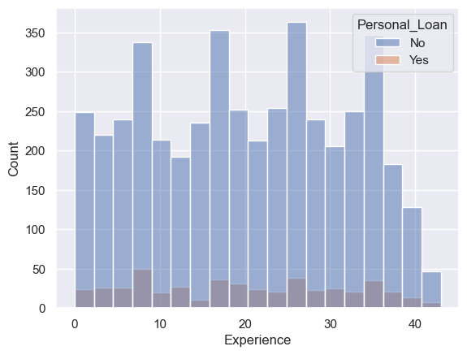

```python
sns.histplot(df_new,x='Experience',hue='Personal_Loan')
```

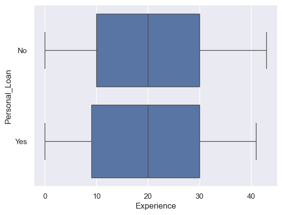

```python
sns.boxplot(df_new,x='Experience',y='Personal_Loan')
```

### Others

```python
# Number of customer accept the personal loan offered in the last campaign
df_new['Personal_Loan'].value_counts()['Yes']
```

```
480
```

```python
# Number of customer have securities account with the bank
df_new['Securities_Account'].value_counts()['Yes']
```

```
522
```

```python
# Number of customer have a certificate of deposit (CD) account with the bank
df_new['CD_Account'].value_counts()['Yes']
```

```
302
```

```python
#Number of customers use internet banking facilities
df_new['Online'].value_counts()['Yes']
```

```
2984
```

```python
# he customer have securities account with the bank
df_new['Securities_Account'].value_counts()['Yes']
```

```
522
```

## Data Preprocessing

- Missing value treatment
- Feature engineering (if needed)
- Outlier detection and treatment (if needed)
- Preparing data for modeling
- Any other preprocessing steps (if needed)

```python
# Finding null value
(df_new.isnull()!=0).count()
```

```
ID                    5000
Age                   5000
Experience            5000
Income                5000
ZIPCode               5000
Family                5000
CCAvg                 5000
Education             5000
Mortgage              5000
Personal_Loan         5000
Securities_Account    5000
CD_Account            5000
Online                5000
CreditCard            5000
dtype: int64
```

- No null value

#### Data Correlation

```python
df.corr()
```

|  | ID | Age | Experience | Income | ZIPCode | Family | CCAvg | Education | Mortgage | Personal_Loan | Securities_Account | CD_Account | Online | CreditCard |
| --- | --- | --- | --- | --- | --- | --- | --- | --- | --- | --- | --- | --- | --- | --- |
| ID | 1.000000 | -0.008473 | -0.008326 | -0.017695 | 0.002240 | -0.016797 | -0.024675 | 0.021463 | -0.013920 | -0.024801 | -0.016972 | -0.006909 | -0.002528 | 0.017028 |
| Age | -0.008473 | 1.000000 | 0.994215 | -0.055269 | -0.030530 | -0.046418 | -0.052012 | 0.041334 | -0.012539 | -0.007726 | -0.000436 | 0.008043 | 0.013702 | 0.007681 |
| Experience | -0.008326 | 0.994215 | 1.000000 | -0.046574 | -0.030456 | -0.052563 | -0.050077 | 0.013152 | -0.010582 | -0.007413 | -0.001232 | 0.010353 | 0.013898 | 0.008967 |
| Income | -0.017695 | -0.055269 | -0.046574 | 1.000000 | -0.030709 | -0.157501 | 0.645984 | -0.187524 | 0.206806 | 0.502462 | -0.002616 | 0.169738 | 0.014206 | -0.002385 |
| ZIPCode | 0.002240 | -0.030530 | -0.030456 | -0.030709 | 1.000000 | 0.027512 | -0.012188 | -0.008266 | 0.003614 | -0.002974 | 0.002422 | 0.021671 | 0.028317 | 0.024033 |
| Family | -0.016797 | -0.046418 | -0.052563 | -0.157501 | 0.027512 | 1.000000 | -0.109275 | 0.064929 | -0.020445 | 0.061367 | 0.019994 | 0.014110 | 0.010354 | 0.011588 |
| CCAvg | -0.024675 | -0.052012 | -0.050077 | 0.645984 | -0.012188 | -0.109275 | 1.000000 | -0.136124 | 0.109905 | 0.366889 | 0.015086 | 0.136534 | -0.003611 | -0.006689 |
| Education | 0.021463 | 0.041334 | 0.013152 | -0.187524 | -0.008266 | 0.064929 | -0.136124 | 1.000000 | -0.033327 | 0.136722 | -0.010812 | 0.013934 | -0.015004 | -0.011014 |
| Mortgage | -0.013920 | -0.012539 | -0.010582 | 0.206806 | 0.003614 | -0.020445 | 0.109905 | -0.033327 | 1.000000 | 0.142095 | -0.005411 | 0.089311 | -0.005995 | -0.007231 |
| Personal_Loan | -0.024801 | -0.007726 | -0.007413 | 0.502462 | -0.002974 | 0.061367 | 0.366889 | 0.136722 | 0.142095 | 1.000000 | 0.021954 | 0.316355 | 0.006278 | 0.002802 |
| Securities_Account | -0.016972 | -0.000436 | -0.001232 | -0.002616 | 0.002422 | 0.019994 | 0.015086 | -0.010812 | -0.005411 | 0.021954 | 1.000000 | 0.317034 | 0.012627 | -0.015028 |
| CD_Account | -0.006909 | 0.008043 | 0.010353 | 0.169738 | 0.021671 | 0.014110 | 0.136534 | 0.013934 | 0.089311 | 0.316355 | 0.317034 | 1.000000 | 0.175880 | 0.278644 |
| Online | -0.002528 | 0.013702 | 0.013898 | 0.014206 | 0.028317 | 0.010354 | -0.003611 | -0.015004 | -0.005995 | 0.006278 | 0.012627 | 0.175880 | 1.000000 | 0.004210 |
| CreditCard | 0.017028 | 0.007681 | 0.008967 | -0.002385 | 0.024033 | 0.011588 | -0.006689 | -0.011014 | -0.007231 | 0.002802 | -0.015028 | 0.278644 | 0.004210 | 1.000000 |

```python
df.corr(method='spearman')['Personal_Loan']
```

```
ID                   -0.024801
Age                  -0.008151
Experience           -0.007905
Income                0.430739
ZIPCode              -0.000280
Family                0.061757
CCAvg                 0.313957
Education             0.139492
Mortgage              0.063294
Personal_Loan         1.000000
Securities_Account    0.021954
CD_Account            0.316355
Online                0.006278
CreditCard            0.002802
Name: Personal_Loan, dtype: float64
```

personal Loan most four corr : Income 0.430739 CD_Account 0.316355 CCAvg 0.313957 Education 0.139492

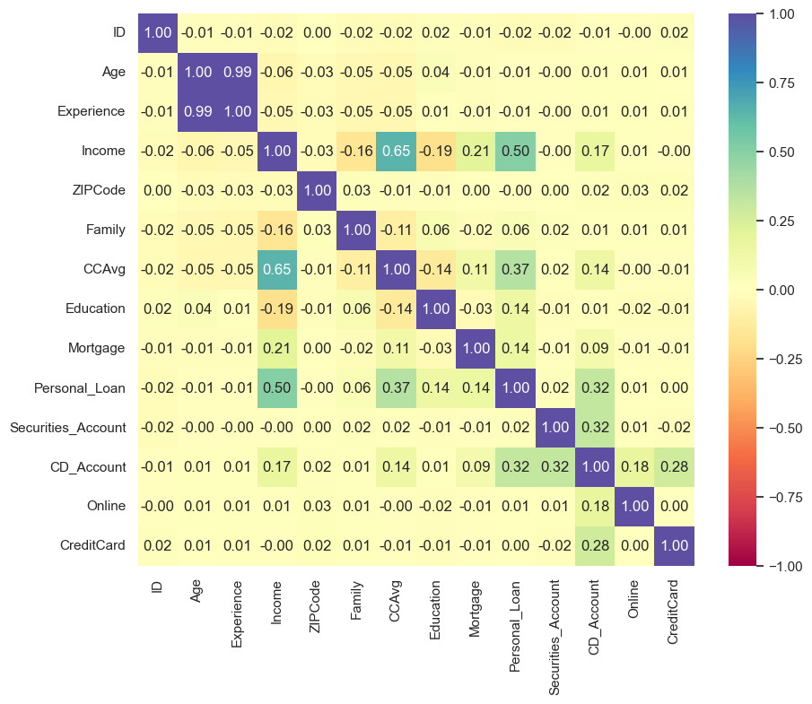

```python
plt.figure(figsize=(10, 8))
sns.heatmap(df.corr(), annot=True, vmin=-1, vmax=1, fmt=".2f", cmap="Spectral")
```

### data types changing

```python
df_new.head()
```

|  | ID | Age | Experience | Income | ZIPCode | Family | CCAvg | Education | Mortgage | Personal_Loan | Securities_Account | CD_Account | Online | CreditCard |
| --- | --- | --- | --- | --- | --- | --- | --- | --- | --- | --- | --- | --- | --- | --- |
| 0 | 1 | 25 | 1 | 49 | 91107 | 4 | 1.6 | Undergraduaate | No | No | Yes | No | No | No |
| 1 | 2 | 45 | 19 | 34 | 90089 | 3 | 1.5 | Undergraduaate | No | No | Yes | No | No | No |
| 2 | 3 | 39 | 15 | 11 | 94720 | 1 | 1.0 | Undergraduaate | No | No | No | No | No | No |
| 3 | 4 | 35 | 9 | 100 | 94112 | 1 | 2.7 | Graduate | No | No | No | No | No | No |
| 4 | 5 | 35 | 8 | 45 | 91330 | 4 | 1.0 | Graduate | No | No | No | No | No | Yes |

```python
df_new['ZIPCode']
```

```
0       91107
1       90089
2       94720
3       94112
4       91330
        ...
4995    92697
4996    92037
4997    93023
4998    90034
4999    92612
Name: ZIPCode, Length: 5000, dtype: int64
```

```python
# Convert numerical to string because ZipCode have  not numarical value
df_new['ZIPCode']=df_new['ZIPCode'].astype(str)
```

```python
df_new['ZIPCode'].nunique()
```

```
467
```

```python
## df_new['ZIPCode']=df['ZIPCode'].copy()
```

```python
# First 2 digit is more important and good for gettin insiths
df_new['ZIPCode'].str[0:2].unique()
```

```
array(['91', '90', '94', '92', '93', '95', '96'], dtype=object)
```

```python
df_new['ZIPCode']=df_new['ZIPCode'].str[0:2]
```

```python
df_new.head()
```

|  | ID | Age | Experience | Income | ZIPCode | Family | CCAvg | Education | Mortgage | Personal_Loan | Securities_Account | CD_Account | Online | CreditCard |
| --- | --- | --- | --- | --- | --- | --- | --- | --- | --- | --- | --- | --- | --- | --- |
| 0 | 1 | 25 | 1 | 49 | 91 | 4 | 1.6 | Undergraduaate | No | No | Yes | No | No | No |
| 1 | 2 | 45 | 19 | 34 | 90 | 3 | 1.5 | Undergraduaate | No | No | Yes | No | No | No |
| 2 | 3 | 39 | 15 | 11 | 94 | 1 | 1.0 | Undergraduaate | No | No | No | No | No | No |
| 3 | 4 | 35 | 9 | 100 | 94 | 1 | 2.7 | Graduate | No | No | No | No | No | No |
| 4 | 5 | 35 | 8 | 45 | 91 | 4 | 1.0 | Graduate | No | No | No | No | No | Yes |

```python
df_new.columns
```

```
Index(['ID', 'Age', 'Experience', 'Income', 'ZIPCode', 'Family', 'CCAvg',
       'Education', 'Mortgage', 'Personal_Loan', 'Securities_Account',
       'CD_Account', 'Online', 'CreditCard'],
      dtype='object')
```

```python
# Catigorical column
df_cat=['ZIPCode', "Education",    "Personal_Loan",    "Securities_Account",
    "CD_Account",    "Online",    "CreditCard"    ]
#conver  type string  to catigorical will reduce memory usage
df_new[df_cat] = df_new[df_cat].astype("category")
```

```python
df_new.dtypes
```

```
ID                       int64
Age                      int64
Experience               int64
Income                   int64
ZIPCode               category
Family                   int64
CCAvg                  float64
Education             category
Mortgage                object
Personal_Loan         category
Securities_Account    category
CD_Account            category
Online                category
CreditCard            category
dtype: object
```

## Exploratory Data Analysis (EDA)

### Bivariable

```python
def HistBoxPlot (data, feature,target):
    # for numerical
    df_yes=data[data[target]=='Yes'].value_counts().reset_index()
    df_no=data[data[target]=='No'].value_counts().reset_index()

    plt.subplot(1,2,1)
    sns.histplot(data=df_no,x=feature ,kde=True , color="orange")
    plt.title(f"{target} NO")


    plt.subplot(1,2,2)
    sns.histplot(data=df_yes,x=feature,kde=True)
    plt.title(f"{target}  Yes")
    plt.show()

    plt.subplot(1,1,1)
    sns.boxplot(data=data,x=feature,color="green",)
    plt.show()

    plt.subplot(1,2,1)
    sns.boxplot(data=data, x=target, y=feature,  palette="gist_rainbow")
    plt.title(f"Boxplot of {target} ")

    plt.subplot(1,2,2)
    sns.boxplot(data=data, x=target, y=feature, showfliers=False,palette='Pastel1'  )
    plt.title(f"Boxplot of {target} without outlier")

    plt.tight_layout()
```

#### 'Experience' Vs 'Personal_Loan')

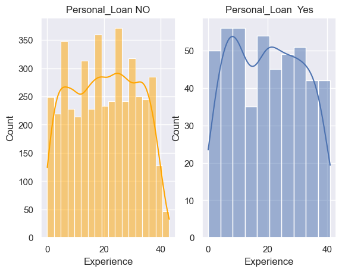

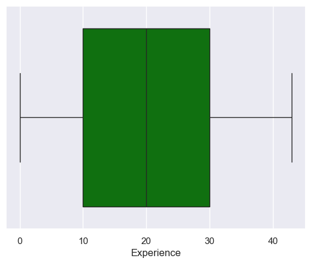

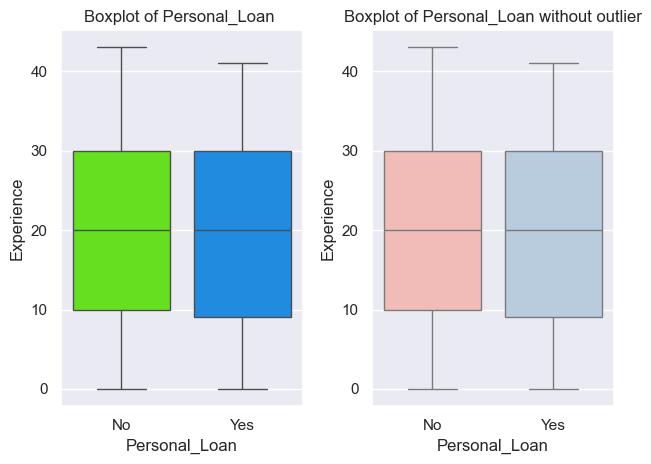

```python
HistBoxPlot (df_new, 'Experience','Personal_Loan')
```

#### 'Age' Vs'Personal_Loan'

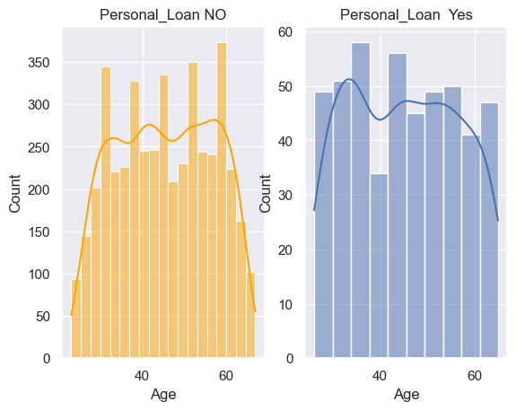

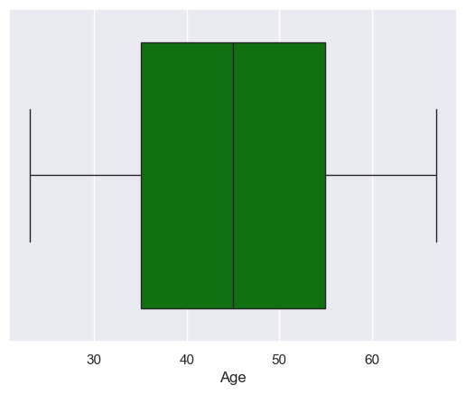

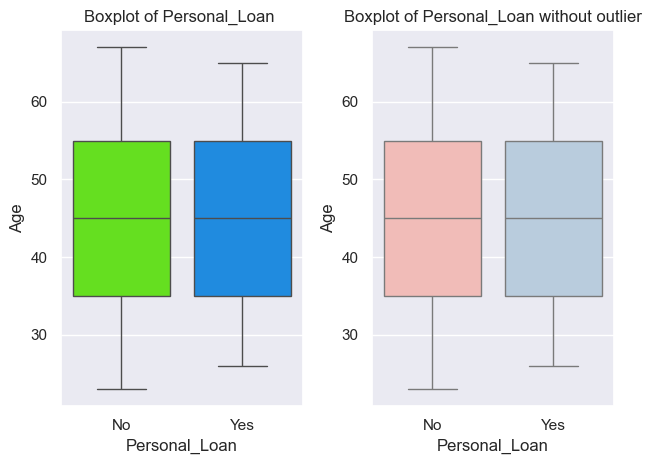

```python
HistBoxPlot (df_new, 'Age','Personal_Loan')
```

#### 'Income' Vs 'Personal_Loan'

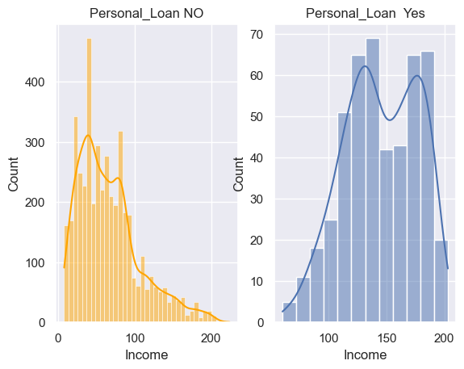

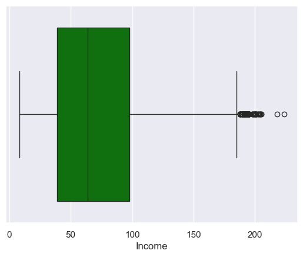

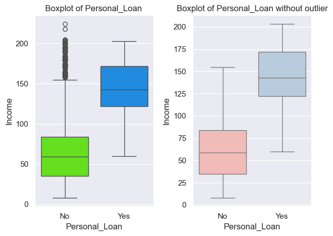

```python
HistBoxPlot (df_new, 'Income','Personal_Loan')
```

##### 'CCAvg' Vs 'Personal_Loan'

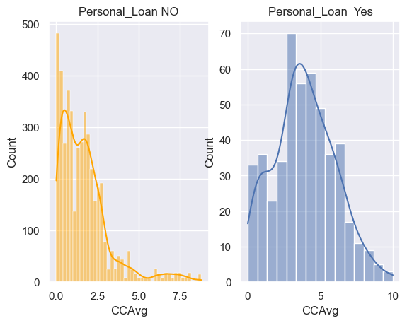

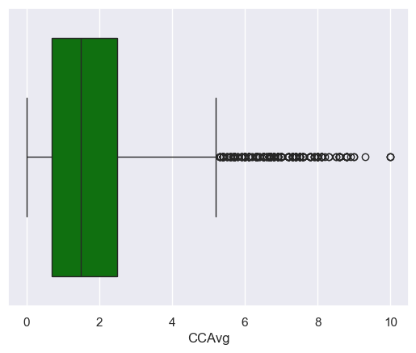

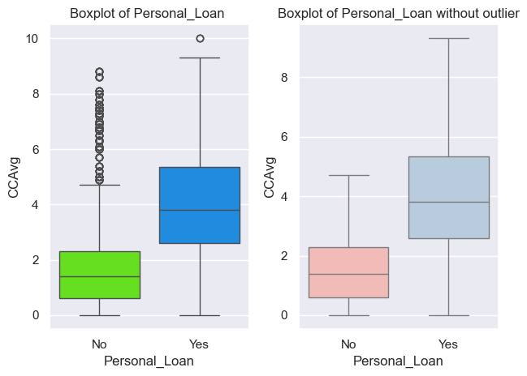

```python
HistBoxPlot (df_new, 'CCAvg','Personal_Loan')
```

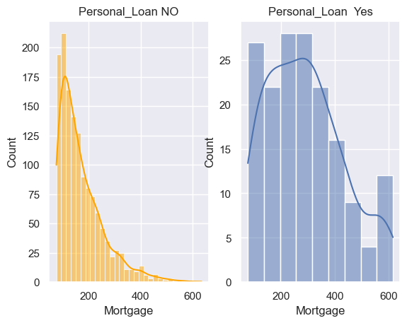

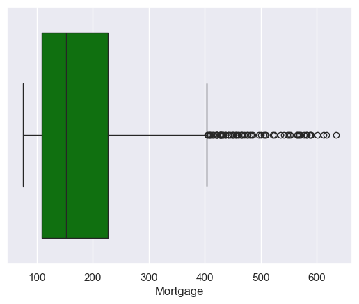

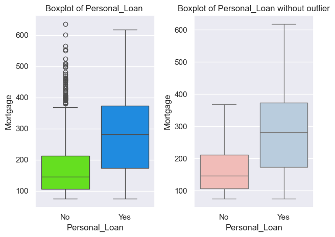

```python
HistBoxPlot (df_new[df['Mortgage']>0], 'Mortgage','Personal_Loan')
```

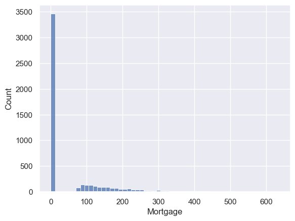

```python
# Plot for who has mortgage
sns.histplot(df,x='Mortgage')
```

### Univariable

```python
# for numerical value
import matplotlib.pyplot as plt
import numpy as np
from matplotlib.ticker import PercentFormatter

def HistLablPlot(d, feature):
    # Sample data numerical
    data = d[feature]
    X_lable=feature
    # Compute histogram heights and bins
    heights, bins = np.histogram(data, bins='auto')  # 'auto' can help determine the optimal number of bins

    # Compute percentages
    percent = [i / sum(heights) * 100 for i in heights]

    # Calculate bin width
    bin_width = np.diff(bins)[0]

    # Create the bar plot with dynamic bin width
    plt.figure(figsize=(20,7))
    plt.bar(bins[:-1], heights, width=bin_width, align="edge", edgecolor="black",color='gold')

    # Add text annotations inside each bar, but only if the percentage is greater than 0
    for i in range(len(bins)-1):
        if percent[i] > 0:  # Check if the percentage is greater than 0
            plt.text(bins[i] + bin_width/2, heights[i], f"{percent[i]:.1f}%", ha="center", va="bottom")

    # Set the x-axis ticks to be at the center of each bin
    plt.xticks(ticks=bins[:-1] + bin_width/2, labels=[f"{bin:.0f}" for bin in bins[:-1]])

    # Customize other plot properties (e.g., labels, title)
    plt.xlabel(X_lable)
    plt.ylabel("Count")
    plt.title("Histogram with Percentages ")

    # Show the plot
    plt.show()
```

#### Plot for Experience

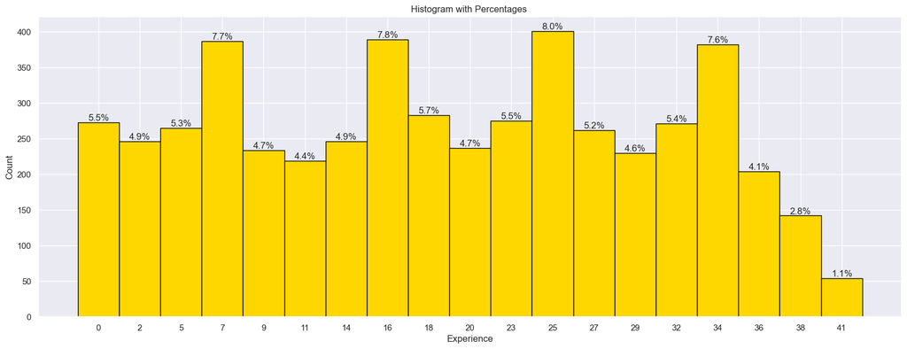

```python
HistLablPlot(df_new, 'Experience')
```

#### Plot for Age

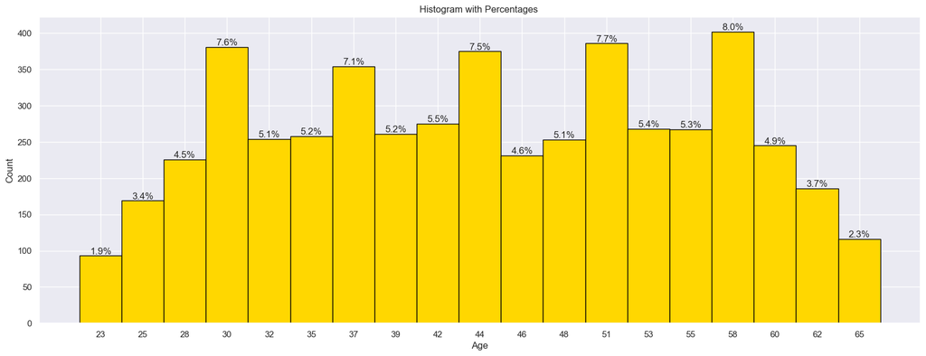

```python
HistLablPlot (df_new,'Age')
```

#### Plot for Income

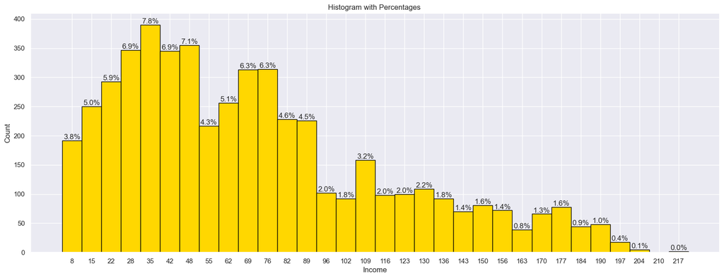

```python
HistLablPlot (df_new,'Income')
```